# **Predicting Breast Cancer Using Clinical Data**

#### Author: Luis Rito Filipe

#### October, 2023

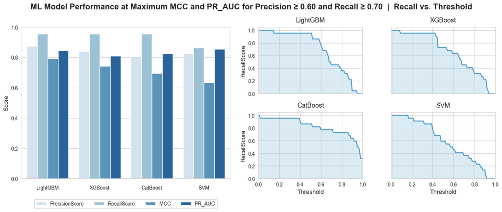

# Summary

This study evaluates multiple machine learning models for predicting breast cancer using clinical data, with the primary objective of minimizing false negative diagnoses while maintaining false positives at an acceptable level.

The results demonstrate that breast cancer prediction is driven by a significative number of highly informative features, particularly Glucose, Resistin, Age, BMI and HOMA, with other variables providing complementary contributions.

Feature engineering had limited impact on model performance, suggesting that the original variables already capture most of the relevant information required for accurate classification.

Although the number of observations in this dataset may be considered relatively limited for drawing definitive clinical conclusions, some features provide sufficiently strong signals for class discrimination.

# About The Study

The objective of this study is to compare different machine learning algorithms in predicting whether patients have breast cancer based on clinical data. To achieve this, widely used Python libraries for data analysis and machine learning are employed, including tools for data manipulation, visualization, and predictive modeling. The study follows a structured approach, beginning with exploratory data analysis (EDA), followed by data preprocessing and feature engineering, and concluding with model training, evaluation, and comparison. The goal is to identify which algorithms perform best under consistent evaluation criteria and to understand the key factors associated with breast cancer prediction.

# About The Dataset

This study uses a dataset of clinical measurements provided by the UCI Machine Learning Repository (see link below). The dataset contains clinical data recorded by trained staff, with checks to ensure accuracy and completeness, including variables such as age, glucose concentration, body mass index (BMI) and other health indicators. The target variable indicates whether a patient was diagnosed with breast cancer.

Dataset link: https://archive.ics.uci.edu/dataset/451/breast+cancer+coimbra

```python
import pandas as pd
import numpy as np
#import time
#import threading
#import csv, sqlite3
#import statistics
import quantitative_and_technical_analytics as qta
import matplotlib.pyplot as plt
import matplotlib.colors as mcolors
from matplotlib.colors import LinearSegmentedColormap, TwoSlopeNorm, Normalize
import matplotlib.gridspec as gridspec
#import plotly.graph_objects as go
from plotly.subplots import make_subplots
import seaborn as sns
#from datetime import date, timedelta
# from ibapi.client  import EClient
# from ibapi.wrapper import EWrapper
# from ibapi.contract import Contract
# from ibapi.ticktype import TickTypeEnum
from sklearn.preprocessing import StandardScaler
from sklearn.feature_selection import mutual_info_classif
from sklearn.pipeline import Pipeline
from sklearn.model_selection import train_test_split
from sklearn.linear_model import LogisticRegression
from sklearn.metrics import confusion_matrix, precision_score, recall_score, f1_score, precision_recall_curve, roc_auc_score, roc_curve, average_precision_score, matthews_corrcoef, log_loss, brier_score_loss
from sklearn.calibration import calibration_curve
from sklearn.model_selection import RandomizedSearchCV, StratifiedKFold, TimeSeriesSplit
from sklearn.svm import SVC
from sklearn.neighbors import KNeighborsClassifier
# from sklearn.tree import DecisionTreeClassifier
from sklearn.ensemble import RandomForestClassifier
from catboost import CatBoostClassifier
from sklearn.neural_network import MLPClassifier
from sklearn.inspection import permutation_importance
from xgboost import XGBClassifier
from lightgbm import LGBMClassifier
import shap
import warnings

pd.set_option('display.max_rows', None)
pd.set_option('display.max_columns', None)
pd.set_option('display.max_colwidth', None)
warnings.filterwarnings("ignore")

def plot_confusion_matrix(y, y_predict):
    cm = confusion_matrix(y, y_predict)
    plt.figure(figsize=(4, 3))
    ax = sns.heatmap(cm, annot=True, fmt="d", cmap="Blues")
    ax.set_xlabel('Predicted labels', fontsize=11, labelpad=10)
    ax.set_ylabel('True labels', fontsize=11, labelpad=10)
    ax.set_title('Confusion Matrix', fontsize=13, pad=14, fontweight="bold")
    ax.xaxis.set_ticklabels(['No cancer', 'Cancer'])
    ax.yaxis.set_ticklabels(['No cancer', 'Cancer'])
    plt.tight_layout()
    plt.show()
```

# Data Wrangling

The dataset contains nine independent variables and one target variable, named Classification.

```python
df = pd.read_csv("Breast_Cancer_Coimbra_Data_Set.csv")
df.info(verbose=False)
df.describe()
```

```
<class 'pandas.core.frame.DataFrame'>
RangeIndex: 116 entries, 0 to 115
Columns: 10 entries, Age to Classification
dtypes: float64(7), int64(3)
memory usage: 9.2 KB
```

|  | Age | BMI | Glucose | Insulin | HOMA | Leptin | Adiponectin | Resistin | MCP.1 | Classification |
| --- | --- | --- | --- | --- | --- | --- | --- | --- | --- | --- |
| count | 116.000000 | 116.000000 | 116.000000 | 116.000000 | 116.000000 | 116.000000 | 116.000000 | 116.000000 | 116.000000 | 116.000000 |
| mean | 57.301724 | 27.582111 | 97.793103 | 10.012086 | 2.694988 | 26.615080 | 10.180874 | 14.725966 | 534.647000 | 0.551724 |
| std | 16.112766 | 5.020136 | 22.525162 | 10.067768 | 3.642043 | 19.183294 | 6.843341 | 12.390646 | 345.912663 | 0.499475 |
| min | 24.000000 | 18.370000 | 60.000000 | 2.432000 | 0.467409 | 4.311000 | 1.656020 | 3.210000 | 45.843000 | 0.000000 |
| 25% | 45.000000 | 22.973205 | 85.750000 | 4.359250 | 0.917966 | 12.313675 | 5.474283 | 6.881763 | 269.978250 | 0.000000 |
| 50% | 56.000000 | 27.662416 | 92.000000 | 5.924500 | 1.380939 | 20.271000 | 8.352692 | 10.827740 | 471.322500 | 1.000000 |
| 75% | 71.000000 | 31.241442 | 102.000000 | 11.189250 | 2.857787 | 37.378300 | 11.815970 | 17.755207 | 700.085000 | 1.000000 |
| max | 89.000000 | 38.578759 | 201.000000 | 58.460000 | 25.050342 | 90.280000 | 38.040000 | 82.100000 | 1698.440000 | 1.000000 |

In the following table, features identified with "True" include rows with missing values.

```python
df.isna().any()
```

```
Age               False
BMI               False
Glucose           False
Insulin           False
HOMA              False
Leptin            False
Adiponectin       False
Resistin          False
MCP.1             False
Classification    False
dtype: bool
```

# Exploratory Data Analysis

One additional feature was engineered to capture non-linear relationships and enhance the predictive power of the models. This feature was designed to reflect meaningful interactions between clinical variables. The High_Glucose feature encodes elevated glucose levels using a nonlinear transformation above a threshold of 140, emphasizing the increased risk associated with higher glucose concentrations. This engineered feature aim to provide models with more informative signals than the original variables alone, particularly in capturing interactions and nonlinear effects.

Other engineered features such as Age_BMI and BMI_Glucose were tested and did not produce better results. Therefore, they were not included. The Classification dependent variable was renamed as Class.

```python
df["High_Glucose"] = np.log1p(np.maximum(0, df["Glucose"] - 140))
df = df.rename(columns={"Classification" : "Class"})
df.describe()
```

|  | Age | BMI | Glucose | Insulin | HOMA | Leptin | Adiponectin | Resistin | MCP.1 | Class | High_Glucose |
| --- | --- | --- | --- | --- | --- | --- | --- | --- | --- | --- | --- |
| count | 116.000000 | 116.000000 | 116.000000 | 116.000000 | 116.000000 | 116.000000 | 116.000000 | 116.000000 | 116.000000 | 116.000000 | 116.000000 |
| mean | 57.301724 | 27.582111 | 97.793103 | 10.012086 | 2.694988 | 26.615080 | 10.180874 | 14.725966 | 534.647000 | 0.551724 | 0.127840 |
| std | 16.112766 | 5.020136 | 22.525162 | 10.067768 | 3.642043 | 19.183294 | 6.843341 | 12.390646 | 345.912663 | 0.499475 | 0.690471 |
| min | 24.000000 | 18.370000 | 60.000000 | 2.432000 | 0.467409 | 4.311000 | 1.656020 | 3.210000 | 45.843000 | 0.000000 | 0.000000 |
| 25% | 45.000000 | 22.973205 | 85.750000 | 4.359250 | 0.917966 | 12.313675 | 5.474283 | 6.881763 | 269.978250 | 0.000000 | 0.000000 |
| 50% | 56.000000 | 27.662416 | 92.000000 | 5.924500 | 1.380939 | 20.271000 | 8.352692 | 10.827740 | 471.322500 | 1.000000 | 0.000000 |
| 75% | 71.000000 | 31.241442 | 102.000000 | 11.189250 | 2.857787 | 37.378300 | 11.815970 | 17.755207 | 700.085000 | 1.000000 | 0.000000 |
| max | 89.000000 | 38.578759 | 201.000000 | 58.460000 | 25.050342 | 90.280000 | 38.040000 | 82.100000 | 1698.440000 | 1.000000 | 4.127134 |

The dataset exhibits a balanced dependent variable, with 55% of observations corresponding to positive breast cancer diagnoses. Feature correlation analysis was performed to identify highly correlated pairs of independent variables, enabling the removal of redundant features and improving model robustness.

A correlation threshold of 0.95 was adopted, such that when two independent variables exhibited an absolute correlation coefficient equal to or greater than this value, the feature with the lower mutual information score relative to the target variable was removed. This approach reduces feature redundancy while preserving the variables with the highest predictive relevance, mitigating multicollinearity effects and decreasing the risk of overfitting

In this dataset, including the engineered features, no pairs of independent variables were found to exceed the defined correlation threshold, as illustrated in the correlation matrix. This indicates that the feature set does not exhibit significant redundancy and can be retained without further dimensionality reduction.

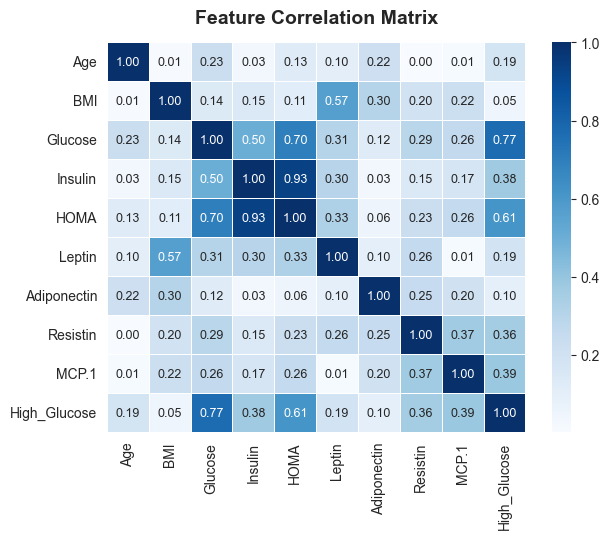

```python
def feature_correlation_check(data, threshold=0.95):
    X = data.drop("Class", axis=1)
    y = data["Class"]
    scaler = StandardScaler()
    X = pd.DataFrame( scaler.fit_transform(X), columns=X.columns, index=X.index )
    corr_matrix_before = X.corr().abs()
    upper = corr_matrix_before.where( np.triu(np.ones(corr_matrix_before.shape), k=1).astype(bool) )
    pairs = upper.stack().reset_index()
    pairs.columns = ["feature_1", "feature_2", "correlation"]
    redundant_pairs = pairs[pairs["correlation"] > threshold].sort_values("correlation", ascending=False)

    mi = mutual_info_classif(X, y)
    mi_lookup = pd.Series(mi, index=X.columns).to_dict()
    to_remove = set()

    for _, row in redundant_pairs.iterrows():
        f1, f2 = row["feature_1"], row["feature_2"]
        mi1 = mi_lookup.get(f1, 0)
        mi2 = mi_lookup.get(f2, 0)
        if mi1 < mi2:
            to_remove.add(f1)
        else:
            to_remove.add(f2)

    corr_matrix_after = X.drop(list(to_remove), axis=1).corr().abs()
    mi = pd.DataFrame({"Feature": X.columns, "MI": mi}).sort_values("MI", ascending=False).reset_index(drop=True).T

    return redundant_pairs, to_remove, corr_matrix_before, corr_matrix_after, mi

redundant_pairs, to_drop, corr_matrix_before, corr_matrix_after, mi = feature_correlation_check(df)
df = df.drop(to_drop, axis=1)
#redundant_pairs

def plot_feature_correlation_matrix(data):
    datalen = len(data)
    fig, ax = plt.subplots(figsize=(0.65 * datalen, 0.55 * datalen))
    sns.heatmap(
        data=data,
        annot=True,
        cmap="Blues",
        fmt=".2f",
        ax=ax,
        annot_kws={"size": 9},
        linewidths=0.5
    )

    ax.set_title("Feature Correlation Matrix", fontsize=14, fontweight="bold", pad=14)
    plt.tight_layout()
    plt.show()
plot_feature_correlation_matrix(corr_matrix_before)
```

The following chart illustrates the correlation between the target variable Class and the independent features. The results indicate that Glucose, HOMA and Insulin exhibit the strongest positive correlations with the target variable, suggesting that higher values of these features are associated with an increased likelihood of belonging to the positive class.

It is important to note that correlation measures linear relationships only and does not capture potential nonlinear interactions between variables. Therefore, features with low correlation may still contribute to model performance when combined with other variables or when nonlinear effects are considered.

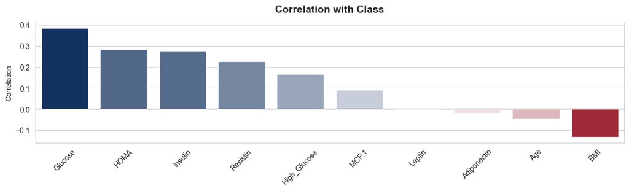

```python
def plot_feature_correlation():
    corr = df.corr()["Class"].drop("Class").sort_values(ascending=False)
    sns.set_style("whitegrid")

    full_cmap = LinearSegmentedColormap.from_list(
        "red_white_blue",
        ["#b2182b", "#ffffff", "#08306b"]
    )
    def get_colors(values):
        vmin, vmax = values.min(), values.max()

        if vmin < 0 and vmax > 0:
            norm = TwoSlopeNorm(vmin=vmin, vcenter=0, vmax=vmax)
            cmap = full_cmap
        elif vmin >= 0:
            norm = Normalize(vmin=vmin, vmax=vmax)
            cmap = LinearSegmentedColormap.from_list(
                "white_blue",
                ["#DEEBF7", "#08306B"]
            )
        else:
            norm = Normalize(vmin=vmin, vmax=vmax)
            cmap = LinearSegmentedColormap.from_list(
                "red_white",
                ["#B2182B", "#DEEBF7"]
            )
        return list(cmap(norm(values)))

    values = corr.values
    colors = get_colors(values)

    fig, ax = plt.subplots(figsize=(13, 3.2))

    sns.barplot(
        x=corr.index,
        y=corr.values,
        hue=corr.index,
        palette=colors,
        legend=False,
        ax=ax
    )

    ax.tick_params(axis='x', rotation=45)
    ax.set_title("Correlation with Class", fontsize=14, fontweight="bold", pad=14)
    ax.set_xlabel(None)
    ax.set_ylabel("Correlation")
    ax.axhline(y=0, color="black", linewidth=0.3)

    fig.canvas.draw()
    renderer = fig.canvas.get_renderer()
    max_height_px = max(
        label.get_window_extent(renderer=renderer).height
        for label in ax.get_xticklabels()
    )
    dpi = fig.dpi
    extra_height_inch = max_height_px / dpi
    fig.set_size_inches(12, 3 + extra_height_inch)

    plt.tight_layout()
    plt.show()

plot_feature_correlation()
```

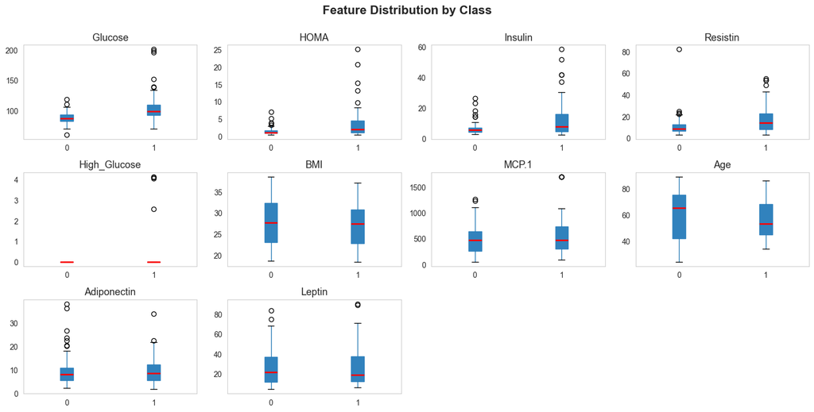

```python
def plot_box_subplots():
    corr = df.corr(numeric_only=True)["Class"].drop("Class").abs().sort_values(ascending=False)
    features = corr.index
    n_features = len(features)
    cols = 4
    rows = int(np.ceil(n_features / cols))
    fig, axes = plt.subplots(rows, cols, figsize=(15, rows * 2.5))

    axes = axes.flatten()

    for i, col in enumerate(features):
        df.boxplot(column=col, by="Class", ax=axes[i], grid=False, boxprops=dict(facecolor="#3182bd", color="#3182bd"), medianprops=dict(color="Red", linewidth=2), patch_artist=True)
        axes[i].set_title(col, fontsize=13)
        axes[i].set_xlabel("")

    for j in range(len(features), len(axes)):
        fig.delaxes(axes[j])

    plt.suptitle("Feature Distribution by Class", y=1.001, fontsize=16, fontweight="bold")
    plt.tight_layout()
    plt.show()

plot_box_subplots()
```

In the next step, the dataset is split into training and testing sets to allow proper training of the classification models and unbiased evaluation of their performance.

```python
models = dict()
X = df.drop("Class", axis=1)
Y = df["Class"]
X_train, X_test, Y_train, Y_test = train_test_split(X, Y, test_size=0.33, random_state=42, stratify=Y)

print('X_train.shape=', X_train.shape, 'Y_train.shape=', Y_train.shape)
print('X_test.shape=', X_test.shape, 'Y_test.shape=', Y_test.shape)
```

```
X_train.shape= (77, 10) Y_train.shape= (77,)
X_test.shape= (39, 10) Y_test.shape= (39,)
```

## Logistic Regression

```python
def run_logistic_regression():
    scaler = StandardScaler()
    X_train_scaled = scaler.fit_transform(X_train)
    X_test_scaled = scaler.transform(X_test)

    parameters = {
            "solver": ['liblinear', 'lbfgs'],
            "class_weight": [{0:1, 1:w} for w in range(1, 16)],
            "C": [0.01, 0.02, 0.05, 0.1, 1],
            "max_iter": [1000]
        }

    lr = LogisticRegression()

    cv = RandomizedSearchCV(
        estimator=lr,
        param_distributions=parameters,
        scoring={"recall": "recall", "f1": "f1", "precision": "precision"},
        refit="f1",
        cv=StratifiedKFold(n_splits=10, shuffle=True, random_state=42),
        verbose=1,
        random_state=42,
        n_jobs=-1
    )

    cv.fit(X_train_scaled, Y_train)
    best_model = cv.best_estimator_
    proba = best_model.predict_proba(X_test_scaled)[:, 1]

    results = []
    for t in np.linspace(0.0, 1.0, 101):
        y_pred = (proba >= t)  # fixed threshold
        cm = confusion_matrix(Y_test, y_pred)
        results.append({
            "Threshold": t,
            "PrecisionScore": precision_score(Y_test, y_pred, zero_division=0),
            "RecallScore": recall_score(Y_test, y_pred, zero_division=0),
            "F1Score": f1_score(Y_test, y_pred, zero_division=0),
            "TP": cm[1, 1],
            "TN": cm[0, 0],
            "FP": cm[0, 1],
            "FN": cm[1, 0],
            "MCC": matthews_corrcoef(Y_test, y_pred)
        })

    df_metrics = pd.DataFrame(results)
    df_metrics.to_csv("log_regression_metrics.csv", index=False)
    df_cv_results = pd.DataFrame(cv.cv_results_)
    df_cv_results.to_csv("log_regression_cv_results.csv", index=False)

    coefficients = best_model.coef_[0]
    feature_names = X.columns
    df_coef = pd.DataFrame({
        "Feature": feature_names,
        "Coefficient": coefficients
    })
    df_coef = df_coef.sort_values("Coefficient", ascending=False).round(3).reset_index(drop=True).transpose()

    return { "metrics": df_metrics, "best_params": cv.best_params_, "best_model": best_model, "coefficients": df_coef, "cv_results": df_cv_results, "y_pred": y_pred, "y_proba": proba }

log_regression = run_logistic_regression()
models.update({"Logistic Regression": log_regression})
```

```python
log_regression["metrics"].iloc[50:55]
```

|  | Threshold | PrecisionScore | RecallScore | F1Score | TP | TN | FP | FN | MCC |
| --- | --- | --- | --- | --- | --- | --- | --- | --- | --- |
| 50 | 0.50 | 0.772727 | 0.772727 | 0.772727 | 17 | 12 | 5 | 5 | 0.478610 |
| 51 | 0.51 | 0.882353 | 0.681818 | 0.769231 | 15 | 15 | 2 | 7 | 0.564171 |
| 52 | 0.52 | 0.866667 | 0.590909 | 0.702703 | 13 | 15 | 2 | 9 | 0.482377 |
| 53 | 0.53 | 0.846154 | 0.500000 | 0.628571 | 11 | 15 | 2 | 11 | 0.402200 |
| 54 | 0.54 | 0.846154 | 0.500000 | 0.628571 | 11 | 15 | 2 | 11 | 0.402200 |

The following table presents the computed feature coefficients from the Logistic Regression model, ordered from highest to lowest.

```python
log_regression["coefficients"]
```

|  | 0 | 1 | 2 | 3 | 4 | 5 | 6 | 7 | 8 | 9 |
| --- | --- | --- | --- | --- | --- | --- | --- | --- | --- | --- |
| Feature | Glucose | HOMA | Insulin | Resistin | High_Glucose | MCP.1 | Age | Leptin | Adiponectin | BMI |
| Coefficient | 0.228 | 0.104 | 0.092 | 0.092 | 0.048 | 0.002 | -0.046 | -0.047 | -0.062 | -0.078 |

A confusion matrix is shown below for a minimum probability equal to the threshold corresponding to a PrecisionScore equal or higher than 0.6 and a RecallScore equal or higher than 0.7.

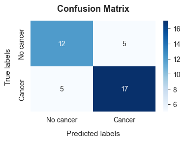

```python
plot_confusion_matrix(Y_test, log_regression["y_proba"] >= log_regression["metrics"][(log_regression["metrics"]["PrecisionScore"] >= 0.60) & (log_regression["metrics"]["RecallScore"] >= 0.70)].sort_values("MCC", ascending=False)["Threshold"].iloc[0] )
```

## Random Forest

```python
def run_random_forest():
    parameters = {
            "class_weight": [{0:1, 1:w} for w in range(1, 16)],
            "n_estimators": [200],
            "max_depth": [5, 15],
            "min_samples_leaf": [5],
            "max_features": ["sqrt"]
        }

    rf = RandomForestClassifier( random_state=42, n_jobs=-1 )

    cv = RandomizedSearchCV(
        estimator=rf,
        param_distributions=parameters,
        n_iter=6,                                                                                       # random combinations
        scoring={"recall": "recall", "f1": "f1", "precision": "precision"},
        refit="f1",
        cv=StratifiedKFold(n_splits=3, shuffle=True, random_state=42),
        verbose=1,
        random_state=42,
        n_jobs=-1
    )

    cv.fit(X_train, Y_train)

    best_model = cv.best_estimator_

    proba = best_model.predict_proba(X_test)[:, 1]

    results = []
    for t in np.linspace(0.0, 1.0, 101):
        y_pred = (proba >= t)
        cm = confusion_matrix(Y_test, y_pred)
        results.append({
            "Threshold": t,
            "PrecisionScore": precision_score(Y_test, y_pred, zero_division=0),
            "RecallScore": recall_score(Y_test, y_pred, zero_division=0),
            "F1Score": f1_score(Y_test, y_pred, zero_division=0),
            "TP": cm[1, 1],
            "TN": cm[0, 0],
            "FP": cm[0, 1],
            "FN": cm[1, 0],
            "MCC": matthews_corrcoef(Y_test, y_pred)
        })

    df_metrics = pd.DataFrame(results)
    df_metrics.to_csv("random_forest_metrics.csv", index=False)
    df_cv_results = pd.DataFrame(cv.cv_results_)
    df_cv_results.to_csv("random_forest_cv_results.csv", index=False)

    importances = best_model.feature_importances_
    df_importances = pd.DataFrame({
        "Feature": X.columns,
        "Importance": importances
    })
    df_importances = df_importances.sort_values("Importance", ascending=False).round(3).reset_index(drop=True).transpose()

    return { "metrics": df_metrics, "best_params": cv.best_params_, "best_model": best_model, "importances": df_importances, "cv_results": df_cv_results, "y_pred": y_pred, "y_proba": proba }

random_forest = run_random_forest()
models.update({"Random Forest": random_forest})
```

```python
random_forest["metrics"].iloc[50:55]
```

|  | Threshold | PrecisionScore | RecallScore | F1Score | TP | TN | FP | FN | MCC |
| --- | --- | --- | --- | --- | --- | --- | --- | --- | --- |
| 50 | 0.50 | 0.678571 | 0.863636 | 0.760000 | 19 | 8 | 9 | 3 | 0.368298 |
| 51 | 0.51 | 0.703704 | 0.863636 | 0.775510 | 19 | 9 | 8 | 3 | 0.422288 |
| 52 | 0.52 | 0.730769 | 0.863636 | 0.791667 | 19 | 10 | 7 | 3 | 0.475327 |
| 53 | 0.53 | 0.750000 | 0.818182 | 0.782609 | 18 | 11 | 6 | 4 | 0.474201 |
| 54 | 0.54 | 0.782609 | 0.818182 | 0.800000 | 18 | 12 | 5 | 4 | 0.528319 |

The following table shows the computed feature importance ordered from highest to lowest.

```python
random_forest["importances"]
```

|  | 0 | 1 | 2 | 3 | 4 | 5 | 6 | 7 | 8 | 9 |
| --- | --- | --- | --- | --- | --- | --- | --- | --- | --- | --- |
| Feature | Glucose | Age | BMI | Resistin | HOMA | Leptin | Insulin | Adiponectin | MCP.1 | High_Glucose |
| Importance | 0.317 | 0.132 | 0.119 | 0.091 | 0.087 | 0.079 | 0.064 | 0.058 | 0.053 | 0.0 |

A confusion matrix is shown below for a minimum probability equal to the threshold corresponding to a PrecisionScore equal or higher than 0.6 and a RecallScore equal or higher than 0.7.

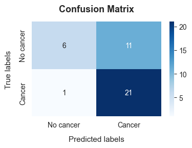

```python
plot_confusion_matrix(Y_test, random_forest["y_proba"] >= random_forest["metrics"][(random_forest["metrics"]["PrecisionScore"] >= 0.60) & (log_regression["metrics"]["RecallScore"] >= 0.70)].sort_values("MCC", ascending=False)["Threshold"].iloc[0] )
```

## XGBoost

```python
def run_xgboost():
    # Note: learning_rate -> estabilidade [0.02-0.05], max_depth -> complexidade [6-12], scale_pos_weight é o parâmetro mais importante para um recall elevado a probabilidades mais elevadas (thresholds)
    scale_pos_weight = len(Y_train[Y_train.eq(0)]) / len(Y_train[Y_train.eq(1)])

    parameters = {
        "n_estimators": [200, 300, 400],
        "max_depth": [0],
        "learning_rate": [0.01, 0.02, 0.05],
        "subsample": [0.7, 0.8, 0.9],
        "colsample_bytree": [0.7, 0.8, 0.9],
        "scale_pos_weight": [scale_pos_weight*0.5, scale_pos_weight, scale_pos_weight*1.5]
    }

    xgb = XGBClassifier( random_state=42, n_jobs=-1, eval_metric="logloss" )

    cv = RandomizedSearchCV(
        estimator=xgb,
        param_distributions=parameters,
        n_iter=20,             # 20 random combinations
        scoring={"recall": "recall", "f1": "f1", "precision": "precision"},
        refit="f1",
        cv=StratifiedKFold(n_splits=10, shuffle=True, random_state=42),                  # cross-validation
        verbose=1,
        random_state=42,
        n_jobs=-1
    )

    cv.fit(X_train, Y_train)

    best_model = cv.best_estimator_

    proba = best_model.predict_proba(X_test)[:, 1]

    results = []
    for t in np.linspace(0.0, 1.0, 101):
        y_pred = (proba >= t)
        cm = confusion_matrix(Y_test, y_pred)
        results.append({
            "Threshold": t,
            "PrecisionScore": precision_score(Y_test, y_pred, zero_division=0),
            "RecallScore": recall_score(Y_test, y_pred, zero_division=0),
            "F1Score": f1_score(Y_test, y_pred, zero_division=0),
            "TP": cm[1, 1],
            "TN": cm[0, 0],
            "FP": cm[0, 1],
            "FN": cm[1, 0],
            "MCC": matthews_corrcoef(Y_test, y_pred)
        })

    df_metrics = pd.DataFrame(results)
    df_metrics.to_csv("xgboost_metrics.csv", index=False)
    df_cv_results = pd.DataFrame(cv.cv_results_)
    df_cv_results.to_csv("xgboost_cv_results.csv", index=False)

    importances = best_model.get_booster().get_score(importance_type="gain")
    df_importances = pd.DataFrame({
        "Feature": X.columns
    })
    df_importances["Importance"] = df_importances["Feature"].map(importances).fillna(0)
    df_importances = df_importances.sort_values("Importance", ascending=False).round().reset_index(drop=True).transpose()

    return { "metrics": df_metrics, "best_params": cv.best_params_, "best_model": best_model, "importances": df_importances, "cv_results": df_cv_results, "y_pred": y_pred, "y_proba": proba }

xgboost = run_xgboost()
models.update({"XGBoost": xgboost})
```

```python
xgboost["metrics"].iloc[50:55]
```

|  | Threshold | PrecisionScore | RecallScore | F1Score | TP | TN | FP | FN | MCC |
| --- | --- | --- | --- | --- | --- | --- | --- | --- | --- |
| 50 | 0.50 | 0.842105 | 0.727273 | 0.780488 | 16 | 14 | 3 | 6 | 0.546436 |
| 51 | 0.51 | 0.842105 | 0.727273 | 0.780488 | 16 | 14 | 3 | 6 | 0.546436 |
| 52 | 0.52 | 0.842105 | 0.727273 | 0.780488 | 16 | 14 | 3 | 6 | 0.546436 |
| 53 | 0.53 | 0.842105 | 0.727273 | 0.780488 | 16 | 14 | 3 | 6 | 0.546436 |
| 54 | 0.54 | 0.882353 | 0.681818 | 0.769231 | 15 | 15 | 2 | 7 | 0.564171 |

The following table shows the computed feature importance ordered from highest to lowest.

```python
xgboost["importances"]
```

|  | 0 | 1 | 2 | 3 | 4 | 5 | 6 | 7 | 8 | 9 |
| --- | --- | --- | --- | --- | --- | --- | --- | --- | --- | --- |
| Feature | Glucose | BMI | Resistin | HOMA | Age | Leptin | Adiponectin | Insulin | MCP.1 | High_Glucose |
| Importance | 3.0 | 2.0 | 2.0 | 2.0 | 2.0 | 1.0 | 1.0 | 1.0 | 1.0 | 0.0 |

A confusion matrix is shown below for a minimum probability equal to the threshold corresponding to a PrecisionScore equal or higher than 0.6 and a RecallScore equal or higher than 0.7.

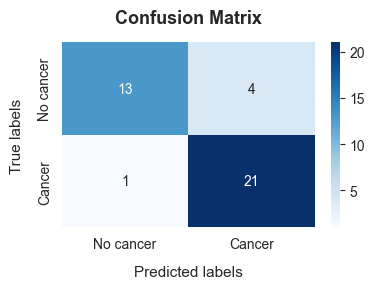

```python
plot_confusion_matrix(Y_test, xgboost["y_proba"] >= xgboost["metrics"][(xgboost["metrics"]["PrecisionScore"] >= 0.60) & (log_regression["metrics"]["RecallScore"] >= 0.70)].sort_values("MCC", ascending=False)["Threshold"].iloc[0] )
```

## LightGBM

```python
def run_light_gbm():
    scale_pos_weight = len(Y_train[Y_train.eq(0)]) / len(Y_train[Y_train.eq(1)])

    parameters = {
        "scale_pos_weight": [scale_pos_weight*0.5, scale_pos_weight, scale_pos_weight*1.5],
        "n_estimators": [200, 300, 400],
        "max_depth": [-1], # -1 = sem restrições
        "num_leaves": [31, 63, 127],
        "learning_rate": [0.01, 0.02, 0.05],
        "subsample": [0.7, 0.8, 0.9],
        "colsample_bytree": [0.7, 0.8, 0.9]
    }

    lgbm = LGBMClassifier( random_state=42, n_jobs=-1 )

    cv = RandomizedSearchCV(
        estimator=lgbm,
        param_distributions=parameters,
        n_iter=13,
        scoring={"recall": "recall", "f1": "f1", "precision": "precision"},
        refit="f1",
        cv=StratifiedKFold(n_splits=10, shuffle=True, random_state=42),
        verbose=1,
        random_state=42,
        n_jobs=-1
    )

    cv.fit(X_train, Y_train)

    best_model = cv.best_estimator_

    proba = best_model.predict_proba(X_test)[:, 1]

    results = []
    for t in np.linspace(0.0, 1.0, 101):
        y_pred = (proba >= t)
        cm = confusion_matrix(Y_test, y_pred)
        results.append({
            "Threshold": t,
            "PrecisionScore": precision_score(Y_test, y_pred, zero_division=0),
            "RecallScore": recall_score(Y_test, y_pred, zero_division=0),
            "F1Score": f1_score(Y_test, y_pred, zero_division=0),
            "TP": cm[1, 1],
            "TN": cm[0, 0],
            "FP": cm[0, 1],
            "FN": cm[1, 0],
            "MCC": matthews_corrcoef(Y_test, y_pred)
        })

    df_metrics = pd.DataFrame(results)
    df_metrics.to_csv("light_gbm_metrics.csv", index=False)
    df_cv_results = pd.DataFrame(cv.cv_results_)
    df_cv_results.to_csv("light_gbm_cv_results.csv", index=False)

    df_importances = pd.DataFrame({
        "Feature": X.columns,
        "Importance": best_model.booster_.feature_importance(importance_type="gain")
    })
    df_importances = df_importances.sort_values("Importance", ascending=False).round().reset_index(drop=True).transpose()

    return { "metrics": df_metrics, "best_params": cv.best_params_, "best_model": best_model, "importances": df_importances, "cv_results": df_cv_results, "y_pred": y_pred, "y_proba": proba }

light_gbm = run_light_gbm()
models.update({"LightGBM": light_gbm})
```

```python
light_gbm["metrics"].iloc[50:55]
```

|  | Threshold | PrecisionScore | RecallScore | F1Score | TP | TN | FP | FN | MCC |
| --- | --- | --- | --- | --- | --- | --- | --- | --- | --- |
| 50 | 0.50 | 0.875000 | 0.954545 | 0.913043 | 21 | 14 | 3 | 1 | 0.793060 |
| 51 | 0.51 | 0.875000 | 0.954545 | 0.913043 | 21 | 14 | 3 | 1 | 0.793060 |
| 52 | 0.52 | 0.863636 | 0.863636 | 0.863636 | 19 | 14 | 3 | 3 | 0.687166 |
| 53 | 0.53 | 0.863636 | 0.863636 | 0.863636 | 19 | 14 | 3 | 3 | 0.687166 |
| 54 | 0.54 | 0.863636 | 0.863636 | 0.863636 | 19 | 14 | 3 | 3 | 0.687166 |

The following table shows the computed feature importance ordered from highest to lowest.

```python
light_gbm["importances"]
```

|  | 0 | 1 | 2 | 3 | 4 | 5 | 6 | 7 | 8 | 9 |
| --- | --- | --- | --- | --- | --- | --- | --- | --- | --- | --- |
| Feature | Glucose | Resistin | Age | BMI | HOMA | Adiponectin | Leptin | MCP.1 | Insulin | High_Glucose |
| Importance | 1142.0 | 805.0 | 438.0 | 239.0 | 179.0 | 63.0 | 22.0 | 21.0 | 21.0 | 0.0 |

A confusion matrix is shown below for a minimum probability equal to the threshold corresponding to a PrecisionScore equal or higher than 0.6 and a RecallScore equal or higher than 0.7.

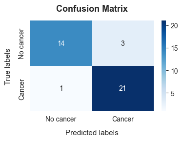

```python
plot_confusion_matrix(Y_test, light_gbm["y_proba"] >= light_gbm["metrics"][(light_gbm["metrics"]["PrecisionScore"] >= 0.60) & (log_regression["metrics"]["RecallScore"] >= 0.70)].sort_values("MCC", ascending=False)["Threshold"].iloc[0] )
```

## CatBoost

```python
def run_cat_boost():

    parameters = {
        "class_weights": [{0:1, 1:w} for w in range(1, 16)],
        "iterations": [300],
        "depth": [4, 6, 8],
        "learning_rate": [0.02, 0.05, 0.1],
        "loss_function": ['Logloss'],
        "eval_metric": ["F1"],
        "verbose": [0]
    }

    catboost = CatBoostClassifier( random_state=42, thread_count=-1 )

    cv = RandomizedSearchCV(
        estimator=catboost,
        param_distributions=parameters,
        n_iter=10,
        scoring={"recall": "recall", "f1": "f1", "precision": "precision"},
        refit="f1",
        cv=StratifiedKFold(n_splits=10, shuffle=True, random_state=42),
        verbose=1,
        random_state=42
    )

    cv.fit(X_train, Y_train)

    best_model = cv.best_estimator_

    proba = best_model.predict_proba(X_test)[:, 1]

    results = []
    for t in np.linspace(0.0, 1.0, 101):
        y_pred = (proba >= t)
        cm = confusion_matrix(Y_test, y_pred)
        results.append({
            "Threshold": t,
            "PrecisionScore": precision_score(Y_test, y_pred, zero_division=0),
            "RecallScore": recall_score(Y_test, y_pred, zero_division=0),
            "F1Score": f1_score(Y_test, y_pred, zero_division=0),
            "TP": cm[1, 1],
            "TN": cm[0, 0],
            "FP": cm[0, 1],
            "FN": cm[1, 0],
            "MCC": matthews_corrcoef(Y_test, y_pred)
        })

    df_metrics = pd.DataFrame(results)
    df_metrics.to_csv("light_gbm_metrics.csv", index=False)
    df_cv_results = pd.DataFrame(cv.cv_results_)
    df_cv_results.to_csv("light_gbm_cv_results.csv", index=False)

    df_importances = pd.DataFrame({
        "Feature": X.columns,
        "Importance": best_model.get_feature_importance()
    })
    df_importances = df_importances.sort_values("Importance", ascending=False).round().reset_index(drop=True).transpose()

    return { "metrics": df_metrics, "best_params": cv.best_params_, "best_model": best_model, "importances": df_importances, "cv_results": df_cv_results, "y_pred": y_pred, "y_proba": proba }

cat_boost = run_cat_boost()
models.update({"CatBoost": cat_boost})
```

```python
cat_boost["metrics"].iloc[50:55]
```

|  | Threshold | PrecisionScore | RecallScore | F1Score | TP | TN | FP | FN | MCC |
| --- | --- | --- | --- | --- | --- | --- | --- | --- | --- |
| 50 | 0.50 | 0.791667 | 0.863636 | 0.826087 | 19 | 12 | 5 | 3 | 0.580487 |
| 51 | 0.51 | 0.791667 | 0.863636 | 0.826087 | 19 | 12 | 5 | 3 | 0.580487 |
| 52 | 0.52 | 0.782609 | 0.818182 | 0.800000 | 18 | 12 | 5 | 4 | 0.528319 |
| 53 | 0.53 | 0.782609 | 0.818182 | 0.800000 | 18 | 12 | 5 | 4 | 0.528319 |
| 54 | 0.54 | 0.782609 | 0.818182 | 0.800000 | 18 | 12 | 5 | 4 | 0.528319 |

The following table shows the computed feature importance ordered from highest to lowest.

```python
cat_boost["importances"]
```

|  | 0 | 1 | 2 | 3 | 4 | 5 | 6 | 7 | 8 | 9 |
| --- | --- | --- | --- | --- | --- | --- | --- | --- | --- | --- |
| Feature | Glucose | Age | Resistin | BMI | MCP.1 | Leptin | Adiponectin | HOMA | Insulin | High_Glucose |
| Importance | 32.0 | 16.0 | 15.0 | 12.0 | 8.0 | 6.0 | 6.0 | 3.0 | 2.0 | 0.0 |

A confusion matrix is shown below for a minimum probability equal to the threshold corresponding to a PrecisionScore equal or higher than 0.6 and a RecallScore equal or higher than 0.7.

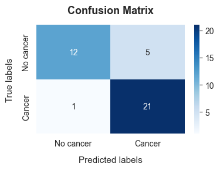

```python
plot_confusion_matrix(Y_test, cat_boost["y_proba"] >= cat_boost["metrics"][(cat_boost["metrics"]["PrecisionScore"] >= 0.60) & (log_regression["metrics"]["RecallScore"] >= 0.70)].sort_values("MCC", ascending=False)["Threshold"].iloc[0] )
```

## Support Vector Machines (SVM)

```python
def run_svm():
    pipeline = Pipeline([
        ("scaler", StandardScaler()),
        ("model", SVC(probability=True, random_state=42))
    ])

    parameters = [
        {
            "model__kernel": ["linear"],
            "model__C": [0.01, 0.1, 1, 10, 100]
        },
        {
            "model__kernel": ["rbf"],
            "model__C": [0.01, 0.1, 1, 10, 100],
            "model__gamma": [0.001, 0.01, 0.1, 1]
        }
    ]

    cv = RandomizedSearchCV(
        estimator=pipeline,
        param_distributions=parameters,
        n_iter=10,
        scoring={"recall": "recall", "f1": "f1", "precision": "precision"},
        refit="f1",
        cv=StratifiedKFold(n_splits=10, shuffle=True, random_state=42),
        verbose=1,
        random_state=42,
        n_jobs=-1
    )

    cv.fit(X_train, Y_train)

    best_model = cv.best_estimator_

    proba = best_model.predict_proba(X_test)[:, 1]

    results = []
    for t in np.linspace(0.0, 1.0, 101):
        y_pred = (proba >= t)
        cm = confusion_matrix(Y_test, y_pred)
        results.append({
            "Threshold": t,
            "PrecisionScore": precision_score(Y_test, y_pred, zero_division=0),
            "RecallScore": recall_score(Y_test, y_pred, zero_division=0),
            "F1Score": f1_score(Y_test, y_pred, zero_division=0),
            "TP": cm[1, 1],
            "TN": cm[0, 0],
            "FP": cm[0, 1],
            "FN": cm[1, 0],
            "MCC": matthews_corrcoef(Y_test, y_pred)
        })

    df_metrics = pd.DataFrame(results)
    df_metrics.to_csv("svm_metrics.csv", index=False)
    df_cv_results = pd.DataFrame(cv.cv_results_)
    df_cv_results.to_csv("svm_cv_results.csv", index=False)

    model = best_model.named_steps["model"]
    if hasattr(model, "coef_"):
        coefficients = model.coef_[0]
    else:
        coefficients = None

    feature_names = X.columns
    df_coef = pd.DataFrame({
        "Feature": feature_names,
        "Coefficient": coefficients
    })
    df_coef = df_coef.sort_values("Coefficient", ascending=False).round(3).reset_index(drop=True).transpose()

    return { "metrics": df_metrics, "best_params": cv.best_params_, "best_model": best_model, "coefficients": df_coef, "cv_results": df_cv_results, "y_pred": y_pred, "y_proba": proba }

svm = run_svm()
models.update({"SVM": svm})
```

```python
svm["metrics"].iloc[50:55]
```

|  | Threshold | PrecisionScore | RecallScore | F1Score | TP | TN | FP | FN | MCC |
| --- | --- | --- | --- | --- | --- | --- | --- | --- | --- |
| 50 | 0.50 | 0.866667 | 0.590909 | 0.702703 | 13 | 15 | 2 | 9 | 0.482377 |
| 51 | 0.51 | 0.866667 | 0.590909 | 0.702703 | 13 | 15 | 2 | 9 | 0.482377 |
| 52 | 0.52 | 0.866667 | 0.590909 | 0.702703 | 13 | 15 | 2 | 9 | 0.482377 |
| 53 | 0.53 | 0.857143 | 0.545455 | 0.666667 | 12 | 15 | 2 | 10 | 0.442232 |
| 54 | 0.54 | 0.857143 | 0.545455 | 0.666667 | 12 | 15 | 2 | 10 | 0.442232 |

Support Vector Machines (SVM) does not provide feature coefficients or importances.

A confusion matrix is shown below for a minimum probability equal to the threshold corresponding to a PrecisionScore equal or higher than 0.6 and a RecallScore equal or higher than 0.7.

[figure not shown]

```python
plot_confusion_matrix(Y_test, cat_boost["y_proba"] >= svm["metrics"][(svm["metrics"]["PrecisionScore"] >= 0.60) & (log_regression["metrics"]["RecallScore"] >= 0.70)].sort_values("MCC", ascending=False)["Threshold"].iloc[0] )
```

## K-Nearest Neighbors (KNN)

```python
def run_knn():
    pipeline = Pipeline([
        ("scaler", StandardScaler()),
        ("model", KNeighborsClassifier(n_jobs=-1))
    ])

    parameters = {
        "model__n_neighbors": [3, 5, 7, 9, 11, 15, 21, 31],
        "model__weights": ["uniform", "distance"],
        "model__p": [1, 2]
    }

    cv = RandomizedSearchCV(
        estimator=pipeline,
        param_distributions=parameters,
        n_iter=10,
        scoring={"recall": "recall", "f1": "f1", "precision": "precision"},
        refit="f1",
        cv=StratifiedKFold(n_splits=10, shuffle=True, random_state=42),
        verbose=1,
        random_state=42,
        n_jobs=-1
    )

    cv.fit(X_train, Y_train)

    best_model = cv.best_estimator_

    proba = best_model.predict_proba(X_test)[:, 1]

    results = []
    for t in np.linspace(0.0, 1.0, 101):
        y_pred = (proba >= t)
        cm = confusion_matrix(Y_test, y_pred)
        results.append({
            "Threshold": t,
            "PrecisionScore": precision_score(Y_test, y_pred, zero_division=0),
            "RecallScore": recall_score(Y_test, y_pred, zero_division=0),
            "F1Score": f1_score(Y_test, y_pred, zero_division=0),
            "TP": cm[1, 1],
            "TN": cm[0, 0],
            "FP": cm[0, 1],
            "FN": cm[1, 0],
            "MCC": matthews_corrcoef(Y_test, y_pred)
        })

    df_metrics = pd.DataFrame(results)
    df_metrics.to_csv("knn_metrics.csv", index=False)
    df_cv_results = pd.DataFrame(cv.cv_results_)
    df_cv_results.to_csv("knn_cv_results.csv", index=False)

    return { "metrics": df_metrics, "best_params": cv.best_params_, "best_model": best_model, "cv_results": df_cv_results, "y_pred": y_pred, "y_proba": proba }

knn = run_knn()
models.update({"K-Nearest Neighbors": knn})
```

```python
knn["metrics"].iloc[50:55]
```

|  | Threshold | PrecisionScore | RecallScore | F1Score | TP | TN | FP | FN | MCC |
| --- | --- | --- | --- | --- | --- | --- | --- | --- | --- |
| 50 | 0.50 | 0.833333 | 0.681818 | 0.750000 | 15 | 14 | 3 | 7 | 0.502667 |
| 51 | 0.51 | 0.833333 | 0.681818 | 0.750000 | 15 | 14 | 3 | 7 | 0.502667 |
| 52 | 0.52 | 0.882353 | 0.681818 | 0.769231 | 15 | 15 | 2 | 7 | 0.564171 |
| 53 | 0.53 | 0.866667 | 0.590909 | 0.702703 | 13 | 15 | 2 | 9 | 0.482377 |
| 54 | 0.54 | 0.866667 | 0.590909 | 0.702703 | 13 | 15 | 2 | 9 | 0.482377 |

KNN algorithm does not provide feature coefficients or feature importances.

A confusion matrix is shown below for a minimum probability equal to the threshold corresponding to a PrecisionScore equal or higher than 0.6 and a RecallScore equal or higher than 0.7.

[figure not shown]

```python
plot_confusion_matrix(Y_test, cat_boost["y_proba"] >= knn["metrics"][(knn["metrics"]["PrecisionScore"] >= 0.60) & (log_regression["metrics"]["RecallScore"] >= 0.70)].sort_values("MCC", ascending=False)["Threshold"].iloc[0] )
```

## Multilayer Perceptron (MLP)

```python
def run_mlp():
    pipeline = Pipeline([
        ("scaler", StandardScaler()),
        ("model", MLPClassifier(random_state=42, max_iter=5000))
    ])

    parameters = {
        "model__hidden_layer_sizes": [(50,), (100,), (50, 50), (100, 50)],
        "model__activation": ["relu", "tanh"],
        "model__alpha": [0.0001, 0.001, 0.01],
        "model__learning_rate_init": [0.001, 0.005, 0.01],
        "model__solver": ["adam", "lbfgs"],
        "model__max_iter": [1000, 2000],
        "model__early_stopping": [True]
    }

    cv = RandomizedSearchCV(
        estimator=pipeline,
        param_distributions=parameters,
        n_iter=10,
        scoring={"recall": "recall", "f1": "f1", "precision": "precision"},
        refit="f1",
        cv=StratifiedKFold(n_splits=10, shuffle=True, random_state=42),
        verbose=1,
        random_state=42,
        n_jobs=-1
    )

    cv.fit(X_train, Y_train)

    best_model = cv.best_estimator_

    proba = best_model.predict_proba(X_test)[:, 1]

    results = []
    for t in np.linspace(0.0, 1.0, 101):
        y_pred = (proba >= t)
        cm = confusion_matrix(Y_test, y_pred)
        results.append({
            "Threshold": t,
            "PrecisionScore": precision_score(Y_test, y_pred, zero_division=0),
            "RecallScore": recall_score(Y_test, y_pred, zero_division=0),
            "F1Score": f1_score(Y_test, y_pred, zero_division=0),
            "TP": cm[1, 1],
            "TN": cm[0, 0],
            "FP": cm[0, 1],
            "FN": cm[1, 0],
            "MCC": matthews_corrcoef(Y_test, y_pred)
        })

    df_metrics = pd.DataFrame(results)
    df_metrics.to_csv("mlp_metrics.csv", index=False)
    df_cv_results = pd.DataFrame(cv.cv_results_)
    df_cv_results.to_csv("mlp_cv_results.csv", index=False)

    importances = permutation_importance(best_model, X_test, Y_test, n_repeats=5, random_state=42).importances_mean
    df_importances = pd.DataFrame({
        "Feature": X.columns,
        "Importance": importances
    })
    df_importances = df_importances.sort_values("Importance", ascending=False).round(3).reset_index(drop=True).transpose()

    return { "metrics": df_metrics, "best_params": cv.best_params_, "best_model": best_model, "importances": df_importances, "cv_results": df_cv_results, "y_pred": y_pred, "y_proba": proba }

mlp = run_mlp()
models.update({"Multilayer Perceptron": mlp})
```

```python
mlp["metrics"].iloc[50:55]
```

|  | Threshold | PrecisionScore | RecallScore | F1Score | TP | TN | FP | FN | MCC |
| --- | --- | --- | --- | --- | --- | --- | --- | --- | --- |
| 50 | 0.50 | 0.75 | 0.681818 | 0.714286 | 15 | 12 | 5 | 7 | 0.384628 |
| 51 | 0.51 | 0.75 | 0.681818 | 0.714286 | 15 | 12 | 5 | 7 | 0.384628 |
| 52 | 0.52 | 0.75 | 0.681818 | 0.714286 | 15 | 12 | 5 | 7 | 0.384628 |
| 53 | 0.53 | 0.75 | 0.681818 | 0.714286 | 15 | 12 | 5 | 7 | 0.384628 |
| 54 | 0.54 | 0.75 | 0.681818 | 0.714286 | 15 | 12 | 5 | 7 | 0.384628 |

The following table shows the computed feature importance ordered from highest to lowest.

```python
mlp["importances"]
```

|  | 0 | 1 | 2 | 3 | 4 | 5 | 6 | 7 | 8 | 9 |
| --- | --- | --- | --- | --- | --- | --- | --- | --- | --- | --- |
| Feature | Resistin | Insulin | HOMA | BMI | Leptin | MCP.1 | High_Glucose | Glucose | Adiponectin | Age |
| Importance | 0.097 | 0.067 | 0.056 | 0.021 | 0.01 | 0.005 | 0.0 | -0.0 | -0.0 | -0.026 |

A confusion matrix is shown below for a minimum probability equal to the threshold corresponding to a PrecisionScore equal or higher than 0.6 and a RecallScore equal or higher than 0.7.

[figure not shown]

```python
plot_confusion_matrix(Y_test, cat_boost["y_proba"] >= mlp["metrics"][(mlp["metrics"]["PrecisionScore"] >= 0.60) & (log_regression["metrics"]["RecallScore"] >= 0.70)].sort_values("MCC", ascending=False)["Threshold"].iloc[0] )
```

## Model Comparison and Selection

The next step is to define the desired model performance objective. In the context of breast cancer diagnosis, minimizing false negatives is prioritized, as failing to identify positive cases has higher clinical risk, while a certain level of false positives is acceptable.

Model selection is therefore performed by first identifying all threshold configurations satisfying the predefined constraints on precision and recall (equal or higher than 0.6 and 0.7, respectively). Within this feasible set, the optimal threshold for each model was selected by maximizing the F1Score, ensuring a balanced trade-off between true positives, true negatives, false positives, and false negatives. This approach guarantees that the selected operating point achieves both the desired sensitivity and an overall balanced classification performance.

```python
def model_comparison():
    df_all = []

    for name, model in models.items():
        df = model["metrics"].copy()
        df["Model"] = name
        cols = ["Threshold", "PrecisionScore", "RecallScore", "F1Score", "TP", "TN", "FP", "FN", "MCC"]
        df = df[["Model"] + [c for c in cols if c in df.columns]]
        logloss = log_loss(Y_test, model["y_proba"])
        brier = brier_score_loss(Y_test, model["y_proba"])
        roc = roc_auc_score(Y_test, model["y_proba"])
        pr = average_precision_score(Y_test, model["y_proba"])
        df["LogLoss"] = logloss
        df["BrierScoreLoss"] = brier
        df["ROC_AUC"] = roc
        df["PR_AUC"] = pr
        df_all.append(df)

    df_all = pd.concat(df_all).reset_index(drop=True)

    # Caso de fraude, mínimo 0.80 >= Recall >= 0.90  -->  escolher o melhor F1Score
    models_best_performance = df_all[(df_all["PrecisionScore"] >= 0.6) & (df_all["RecallScore"] >= 0.7)].sort_values(["F1Score", "ROC_AUC", "MCC"], ascending=[False] * 3).drop_duplicates("Model").reset_index(drop=True)

    return { "models_best_performance": models_best_performance, "comparison_across_threshold": df_all }

df_comparison = model_comparison()
```

```python
df_comparison["models_best_performance"]
```

|  | Model | Threshold | PrecisionScore | RecallScore | F1Score | TP | TN | FP | FN | MCC | LogLoss | BrierScoreLoss | ROC_AUC | PR_AUC |
| --- | --- | --- | --- | --- | --- | --- | --- | --- | --- | --- | --- | --- | --- | --- |
| 0 | LightGBM | 0.50 | 0.875000 | 0.954545 | 0.913043 | 21 | 14 | 3 | 1 | 0.793060 | 0.453376 | 0.132488 | 0.879679 | 0.845274 |
| 1 | XGBoost | 0.33 | 0.840000 | 0.954545 | 0.893617 | 21 | 13 | 4 | 1 | 0.743503 | 0.496507 | 0.151791 | 0.852941 | 0.810433 |
| 2 | CatBoost | 0.36 | 0.807692 | 0.954545 | 0.875000 | 21 | 12 | 5 | 1 | 0.694709 | 0.556657 | 0.146682 | 0.852941 | 0.826913 |
| 3 | SVM | 0.38 | 0.826087 | 0.863636 | 0.844444 | 19 | 13 | 4 | 3 | 0.633444 | 0.554708 | 0.186467 | 0.823529 | 0.854744 |
| 4 | Random Forest | 0.56 | 0.818182 | 0.818182 | 0.818182 | 18 | 13 | 4 | 4 | 0.582888 | 0.573698 | 0.190820 | 0.807487 | 0.799770 |
| 5 | K-Nearest Neighbors | 0.43 | 0.782609 | 0.818182 | 0.800000 | 18 | 12 | 5 | 4 | 0.528319 | 0.560493 | 0.188311 | 0.791444 | 0.839653 |
| 6 | Logistic Regression | 0.50 | 0.772727 | 0.772727 | 0.772727 | 17 | 12 | 5 | 5 | 0.478610 | 0.625918 | 0.218938 | 0.772727 | 0.851855 |
| 7 | Multilayer Perceptron | 0.03 | 0.739130 | 0.772727 | 0.755556 | 17 | 11 | 6 | 5 | 0.423194 | 2.581622 | 0.296877 | 0.786096 | 0.813748 |

The model comparison results indicate that several tree-based ensemble methods, including LightGBM, XGBoost and CatBoost, achieve identical RecallScore under the defined constraints. These models reach high recall while maintaining high precision and a relatively low number of false positives, resulting in strong PR_AUC scores.

This convergence in performance suggests that classes are separable. Among the top-performing models, LightGBM shows advantage in probabilistic calibration, as reflected by its lower LogLoss and Brier Score.

Overall, these results indicate that LightGBM is capable of achieving good classification performance, providing the most reliable probability estimates among all the models tested in this dataset.

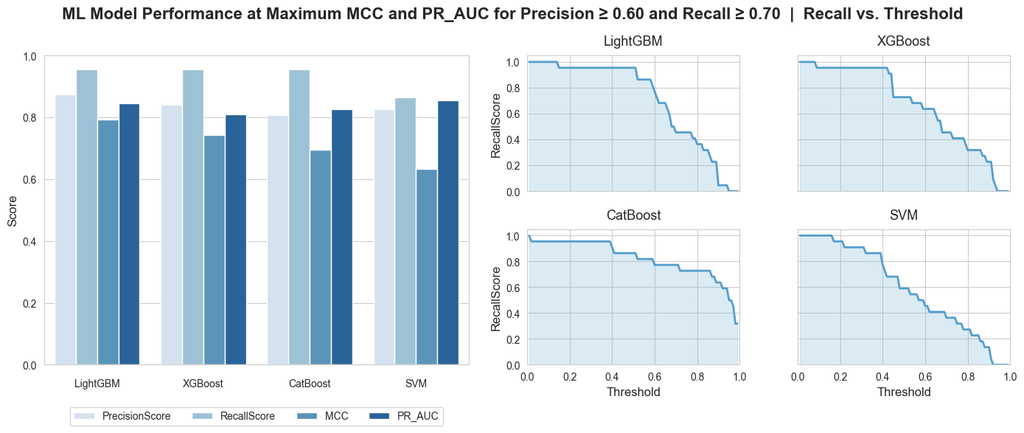

```python
def plot_model_comparison():

    fig = plt.figure(figsize=(14, 6))
    fig.suptitle( "ML Model Performance at Maximum MCC and PR_AUC for Precision ≥ 0.60 and Recall ≥ 0.70  |  Recall vs. Threshold", y=0.98, fontsize=16, fontweight="bold" )
    gs = gridspec.GridSpec(2, 3, width_ratios=[2, 1, 1])

    df_comparison_filtered = df_comparison["comparison_across_threshold"][df_comparison["comparison_across_threshold"]["Model"].isin(list(df_comparison["models_best_performance"]["Model"].head(4)))]
    data = df_comparison_filtered[~df_comparison_filtered["Threshold"].isin([0.0, 1.0])]

    df_melt = df_comparison["models_best_performance"].head(4).melt(
        id_vars="Model",
        value_vars=["PrecisionScore", "RecallScore", "MCC", "PR_AUC"]
    )

    ax_main = fig.add_subplot(gs[:, 0])

    sns.barplot(
        data=df_melt,
        x="Model",
        y="value",
        hue="variable",
        ax=ax_main,
        palette="Blues" # "Blues", "Reds", "Oranges", "Greens", "Purples", "Greys", "Blues", "deep", "muted", "dark", "colorblind",
    )

    ax_main.set_ylabel("Score", fontsize=12)
    ax_main.set_ylim(0, 1)
    ax_main.set_xlabel("")
    ax_main.tick_params(axis='x', rotation=0, pad=10)
    ax_main.legend(loc="upper center", bbox_to_anchor=(0.5, -0.12), ncol=df_melt["variable"].nunique())

    ax1 = fig.add_subplot(gs[0, 1])
    ax2 = fig.add_subplot(gs[0, 2], sharey=ax1)
    ax3 = fig.add_subplot(gs[1, 1], sharex=ax1)
    ax4 = fig.add_subplot(gs[1, 2], sharex=ax2, sharey=ax3)
    axes_right = [ax1, ax2, ax3, ax4]

    for ax in [ax1, ax2]:
        ax.tick_params(labelbottom=False)
    for ax in [ax2, ax4]:
        ax.tick_params(labelleft=False)

    models = df_comparison["models_best_performance"]["Model"].head(4)

    for ax, model in zip(axes_right, models):

        data_model = data[data["Model"] == model]
        df_long = data_model.melt(
            id_vars="Threshold",
            value_vars=["RecallScore"],
            var_name="Metric",
            value_name="Score"
        )

        palette = sns.color_palette("Blues")
        sns.lineplot(
            data=df_long,
            x="Threshold",
            y="Score",
            ax=ax,
            color=palette[3],
            linewidth=2
        )

        ax.set_title(model, fontsize=13, pad=10)
        ax.fill_between( df_long["Threshold"], df_long["Score"], color=palette[2], alpha=0.3 )
        ax.set_ylim(0, 1.05)
        ax.set_xlim(0, 1)
        ax.set_xlabel("Threshold", fontsize=12)
        ax.set_ylabel("RecallScore", fontsize=12)

    plt.tight_layout()
    plt.show()

plot_model_comparison()
```

In the score distribution plots, the horizontal axis represents the predicted probability of belonging to the positive class. A model with strong discriminative ability assigns low probabilities to negative cases (concentrated near 0) and high probabilities to positive cases (concentrated near 1).

The overlap between the two distributions corresponds to regions where both classes receive similar predicted probabilities, leading to potential misclassifications. This overlap is not limited to the intersection point of the curves but represents the entire shared area where both class densities are non-zero.

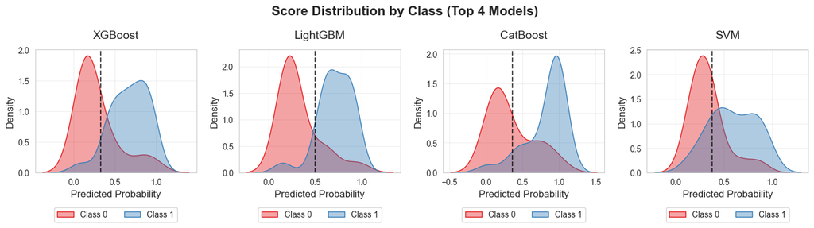

```python
def model_score_distribution_by_class():
    valid_models = set(df_comparison["models_best_performance"]["Model"].head(4))
    filtered_models = {k: v for k, v in models.items() if k in valid_models}

    fig, axes = plt.subplots(1, 4, figsize=(14, 4.2))

    for i, (name, model) in enumerate(filtered_models.items()):
        y_proba = model["y_proba"]

        palette = sns.color_palette("Set1")

        sns.kdeplot(
            y_proba[Y_test == 0],
            fill=True,
            alpha=0.4,
            label="Class 0",
            color=palette[0],
            ax=axes[i]
        )

        sns.kdeplot(
            y_proba[Y_test == 1],
            fill=True,
            alpha=0.4,
            label="Class 1",
            color=palette[1],
            ax=axes[i]
        )

        threshold = df_comparison["models_best_performance"].loc[
            df_comparison["models_best_performance"]["Model"] == name, "Threshold"
        ].values[0]

        axes[i].axvline(threshold, color="black", linestyle="--", alpha=0.7)

        axes[i].set_title(name, fontsize=14, pad=14)
        axes[i].set_xlabel("Predicted Probability", fontsize=12)
        axes[i].set_ylabel("Density", fontsize=12)
        axes[i].grid(True, alpha=0.3)
        axes[i].legend(loc="upper center", bbox_to_anchor=(0.5, -0.25), ncol=4)

    plt.suptitle("Score Distribution by Class (Top 4 Models)", y=0.98, fontsize=16, fontweight="bold")
    plt.tight_layout()
    plt.show()

model_score_distribution_by_class()
```

The SHAP summary plot indicates that breast cancer prediction is primarily driven by a subset of features, with Glucose and Resistin exhibiting the strongest overall impact on the model’s output, followed by Age, BMI and HOMA. Higher values of Glucose and Resistin consistently increase the predicted probability of breast cancer, while lower values are associated with a sharp decrease in predicted risk. Mixed values observed in Age, BMI and HOMA make it difficult to conclude about the contributions of these features.

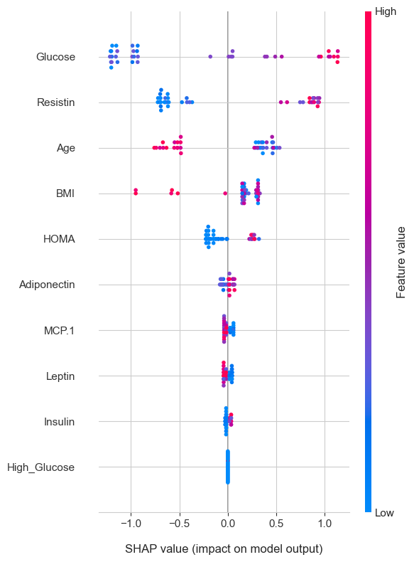

```python
def features_impact(model):
    warnings.filterwarnings("ignore", message=f"{df_comparison["models_best_performance"]["Model"].iloc[0]} binary classifier with TreeExplainer shap values output has changed")
    explainer = shap.TreeExplainer(model)
    shap_values = explainer.shap_values(X_test)
    return shap_values

def plot_summary_plot(model):
    shap_values = features_impact(model)
    shap.summary_plot(shap_values, X_test, plot_size=(6, 8), show=False)
    ax = plt.gca()
    ax.tick_params(axis='y', labelsize=11)
    ax.tick_params(axis='x', labelsize=11)
    plt.xlabel("SHAP value (impact on model output)", fontsize=12, labelpad=15)
    plt.tight_layout()
    plt.show()

plot_summary_plot(models[df_comparison["models_best_performance"]["Model"].iloc[0]]['best_model'])
```

## Conclusion

Although the number of observations in this dataset may be considered relatively limited for drawing definitive clinical conclusions, the results indicate that the available features reliably capture relevant patient conditions and provide sufficiently strong signals for class discrimination.

The inclusion of engineered features did not substantially improve model performance in terms of positive case detection or false negative reduction. This suggests that the original variables already contain a high level of predictive information and that the additional engineered features introduced limited incremental value for this particular dataset.

Overall, the results indicate that model performance is primarily driven by a subset of highly informative variables, particularly Glucose and Resistin, while the remaining features contribute complementary but comparatively weaker predictive information. These findings suggest that the dataset possesses a good underlying signal structure, enabling a solid classification performance even with relatively simple feature representations.